# Pseudobulk QC

## Understanding the discrepancy between our re-analysis of vQTL data and EB-IPSC analysis

First, does running more tests make a huge difference? 1. Subset to the intersection of tests run in both analyses 2. Perform MTC again 3. Compare the number of hits

```r
overlap_tests <- intersect(ebqtl_strict_all$gv, vqtl_all$gv)
overlap_tests <- intersect(overlap_tests, ebqtl_all$gv)
overlap_tests <- intersect(overlap_tests, ebqtl_tmm_all$gv)
vqtl_overlap <- filter(vqtl_all, gv %in% overlap_tests)  # 952623 of 990328
ebqtl_overlap <- filter(ebqtl_all, gv %in% overlap_tests) # 915000 of 1965203
ebqtl_strict_overlap <- filter(ebqtl_strict_all, gv %in% overlap_tests) # 920454 of 1768879
ebqtl_tmm_overlap <- filter(ebqtl_tmm_all, gv %in% overlap_tests)

vqtl_overlap <- vqtl_overlap %>%
  group_by(gene) %>% add_count() %>%
  mutate(bonf.p=if_else(`p-value`*n>1, 1, `p-value`*n)) %>%
  select(-n)

ebqtl_overlap <- ebqtl_overlap %>%
  group_by(gene) %>% add_count() %>%
  mutate(bonf.p=if_else(`p-value`*n>1, 1, `p-value`*n)) %>%
  select(-n)

ebqtl_strict_overlap <- ebqtl_strict_overlap %>%
  group_by(gene) %>% add_count() %>%
  mutate(bonf.p=if_else(`p-value`*n>1, 1, `p-value`*n)) %>%
  select(-n)

ebqtl_tmm_overlap <- ebqtl_tmm_overlap %>%
  group_by(gene) %>% add_count() %>%
  mutate(bonf.p=if_else(`p-value`*n>1, 1, `p-value`*n)) %>%
  select(-n)

vqtl_overlap_tophits <- vqtl_overlap %>%
  group_by(gene) %>%
  arrange(bonf.p) %>%
  filter(!duplicated(gene))
vqtl_overlap_tophits$q <- qvalue(vqtl_overlap_tophits$bonf.p)$qvalues

ebqtl_overlap_tophits <- ebqtl_overlap %>%
  group_by(gene) %>%
  arrange(bonf.p) %>%
  filter(!duplicated(gene))
ebqtl_overlap_tophits$q <- qvalue(ebqtl_overlap_tophits$bonf.p)$qvalues

ebqtl_strict_overlap_tophits <- ebqtl_strict_overlap %>%
  group_by(gene) %>%
  arrange(bonf.p) %>%
  filter(!duplicated(gene))
ebqtl_strict_overlap_tophits$q <- qvalue(ebqtl_strict_overlap_tophits$bonf.p)$qvalues

ebqtl_tmm_overlap_tophits <- ebqtl_tmm_overlap %>%
  group_by(gene) %>%
  arrange(bonf.p) %>%
  filter(!duplicated(gene))
ebqtl_tmm_overlap_tophits$q <- qvalue(ebqtl_tmm_overlap_tophits$bonf.p)$qvalues
```

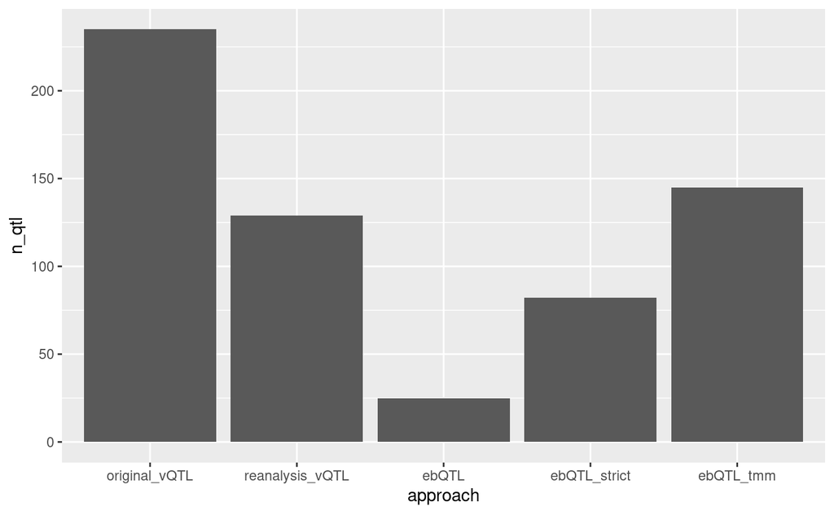

```r
tibble("approach"=factor(c("original_vQTL", "reanalysis_vQTL", "ebQTL", "ebQTL_strict", "ebQTL_tmm"),
                         levels=c("original_vQTL", "reanalysis_vQTL", "ebQTL", "ebQTL_strict", "ebQTL_tmm")),
       "n_qtl"=c(235, sum(vqtl_overlap_tophits$q <= 0.1),
                 sum(ebqtl_overlap_tophits$q <= 0.1), sum(ebqtl_strict_overlap_tophits$q <= 0.1),
                 sum(ebqtl_tmm_overlap_tophits$q <= 0.1))) %>%
  ggplot(aes(x=approach, y=n_qtl)) +
  geom_bar(stat="identity")
```

So this is not likely to just be a matter of how FDR control was performed across genes, there’s something different about the individual tests

How do our effect sizes and standard errors match between the two analyses?

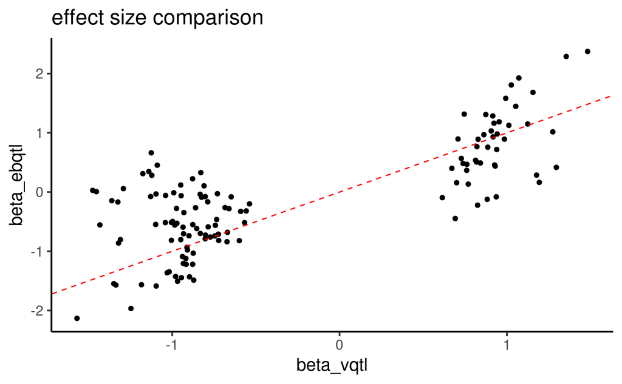

```r
vqtl_stats <- vqtl_overlap_tophits %>%
  filter(q <= 0.1) %>%
  ungroup() %>%
  mutate(se=beta/`t-stat`) %>%
  select(gv, beta, se) %>%
  rename(beta_vqtl=beta, se_vqtl=se)
combined_stats <- ebqtl_tmm_overlap %>%
  ungroup() %>%
  mutate(se=beta/`t-stat`) %>%
  select(gv, beta, se) %>%
  rename(beta_ebqtl=beta, se_ebqtl=se) %>%
  right_join(vqtl_stats, by="gv")

ggplot(combined_stats, aes(x=beta_vqtl, y=beta_ebqtl)) +
  geom_point() +
  geom_abline(slope=1, intercept=0, linetype="dashed", color="red") +
  theme_classic(base_size=15) +
  ylab("beta_ebqtl") + xlab("beta_vqtl") + ggtitle("effect size comparison")
```

```r
cor(combined_stats$beta_ebqtl, combined_stats$beta_vqtl)
```

```
[1] 0.7618241
```

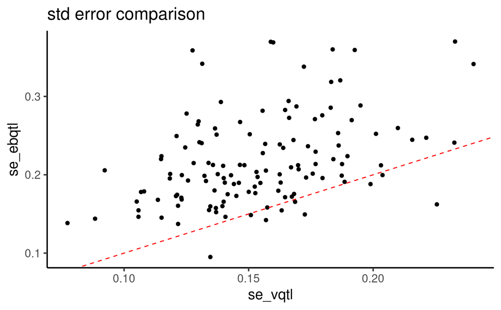

```r
ggplot(combined_stats, aes(x=se_vqtl, y=se_ebqtl)) +
  geom_point() +
  geom_abline(slope=1, intercept=0, linetype="dashed", color="red") +
  theme_classic(base_size=15) +
  ylab("se_ebqtl") + xlab("se_vqtl") + ggtitle("std error comparison")
```

```r
cor(combined_stats$beta_ebqtl, combined_stats$beta_vqtl)
```

```
[1] 0.7618241
```

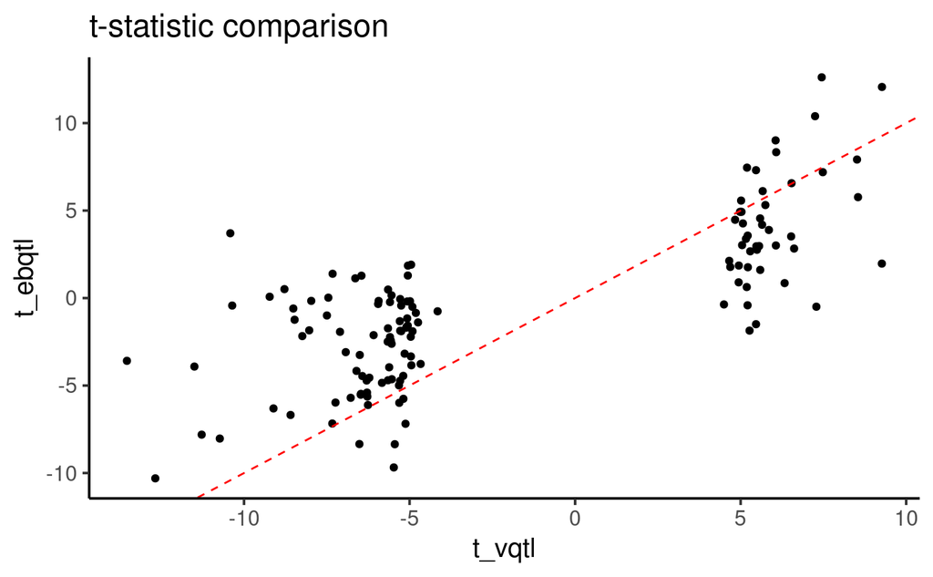

```r
ggplot(combined_stats, aes(x=beta_vqtl/se_vqtl, y=beta_ebqtl/se_ebqtl)) +
  geom_point() +
  geom_abline(slope=1, intercept=0, linetype="dashed", color="red") +
  theme_classic(base_size=15) +
  ylab("t_ebqtl") + xlab("t_vqtl") + ggtitle("t-statistic comparison")
```

## Trying to find upstream causes

Does gene expression generally agree across the two datasets?

```r
sarkar_exp <- read_tsv("/project2/gilad/jpopp/ebQTL/data/single_cell_objects/vqtl_ipsc.pseudobulk-scran.tsv") %>%
  pivot_longer(!gene, names_to="sample", values_to="sarkar_exp")
eb_exp <- read_tsv("/project2/gilad/jpopp/ebQTL/data/single_cell_objects/ebqtl_ipsc.pseudobulk-scran.tsv") %>%
  pivot_longer(!gene, names_to="sample", values_to="eb_exp")

all_exp <- inner_join(sarkar_exp, eb_exp, by=c("gene", "sample"))

ipsc_markers <- c("POU5F1", "NANOG", "GAL", "UTF1", "GDF3", "FGF4",
 "LIN28A", "TFCP2L1", "DNMT3B", "NODAL", "TDGF1", "TRF1",
 "GDF3", "DPPA3", "DPPA5")

all_exp <- all_exp %>%
  mutate(marker=gene %in% ipsc_markers) %>%
  arrange(marker)
```

```r
ggplot(all_exp, aes(x=sarkar_exp, y=eb_exp, color=marker)) +
  scale_color_manual(values=c("black", "red")) +
  facet_wrap(~sample) +
  geom_point(size=1) +
  geom_abline(slope=1, intercept=0, linetype="dashed", color="red")
```

[output not shown]

```r
sample_summary <- read_tsv("/project2/gilad/jpopp/ebQTL/data/static/ebqtl_ipsc/pseudobulk-scran/sample_summary.tsv") %>%
  mutate(individual=factor(individual), type=factor(type))

size_ordered <- sample_summary %>%
  arrange(desc(n_cells)) %>%
  pull(individual) %>%
  as.character

all_exp <- all_exp %>%
  mutate(individual=factor(str_sub(sample, 1, 5), levels=size_ordered))
```

```r
ggplot(all_exp, aes(x=sarkar_exp, y=eb_exp, color=marker)) +
  scale_color_manual(values=c("black", "red")) +
  facet_wrap(~individual) +
  geom_point(size=1) +
  geom_abline(slope=1, intercept=0, linetype="dashed", color="red")
```

Does this hold up after quantile normalization?

```r
invnorm_transform <- function(x) {
  qqnorm(x, plot.it=F)$x
}

sarkar_exp_norm <- read_tsv("/project2/gilad/jpopp/ebQTL/data/single_cell_objects/vqtl_ipsc.pseudobulk-scran.tsv") %>%
  mutate(across(!gene, invnorm_transform)) %>%
  pivot_longer(!gene, names_to="sample", values_to="sarkar_exp")

eb_exp_norm <- read_tsv("/project2/gilad/jpopp/ebQTL/data/single_cell_objects/ebqtl_ipsc.pseudobulk-scran.tsv") %>%
  mutate(across(!gene, invnorm_transform)) %>%
  pivot_longer(!gene, names_to="sample", values_to="eb_exp")

all_exp_norm <- inner_join(sarkar_exp_norm, eb_exp_norm, by=c("gene", "sample")) %>%
  mutate(marker=gene %in% ipsc_markers) %>%
  arrange(marker) %>%
  mutate(individual=factor(str_sub(sample, 1, 5), levels=size_ordered))
```

```r
ggplot(all_exp_norm, aes(x=sarkar_exp, y=eb_exp, color=marker)) +
  scale_color_manual(values=c("black", "red")) +
  facet_wrap(~individual) +
  geom_point(size=1) +
  geom_abline(slope=1, intercept=0, linetype="dashed", color="red")
```

How does this look if we’re extremely conservative with our gene filter?

```r
eb_gene_vars <- rowVars(eb_exp.mat) > 0
eb_gene_highexp <- rowMedians(eb_exp.mat) > 0.25
eb_gene_keepers_strict <- rownames(eb_exp.mat)[eb_gene_vars & eb_gene_highexp]
eb_exp.mat_strict <- eb_exp.mat[eb_gene_keepers_strict,]

eb_exp.mat_strict.t1 <- apply(eb_exp.mat_strict, 2, invnorm_transform)
rownames(eb_exp.mat_strict.t1) <- eb_gene_keepers_strict

eb_exp_t1_strict <- as_tibble(eb_exp.mat_strict.t1, rownames="gene") %>%
  pivot_longer(!gene, names_to="sample", values_to="eb_exp")

all_exp_t1_strict <- inner_join(sarkar_exp_t1, eb_exp_t1_strict, by=c("gene", "sample"))
```

```r
ggplot(all_exp_t1_strict, aes(x=sarkar_exp, y=eb_exp)) +
  facet_wrap(~sample) +
  geom_point() +
  geom_abline(slope=1, intercept=0, linetype="dashed", color="red")
```

## Comparison with stricter filtering in place

```r
vqtl_stats <- vqtl_overlap_tophits %>%
  filter(q <= 0.1) %>%
  ungroup() %>%
  mutate(se=beta/`t-stat`) %>%
  select(gv, beta, se, `t-stat`) %>%
  rename(beta_vqtl=beta, se_vqtl=se, t_vqtl=`t-stat`)
combined_stats_strict <- ebqtl_strict_overlap %>%
  ungroup() %>%
  mutate(se=beta/`t-stat`) %>%
  select(gv, beta, se, `t-stat`) %>%
  rename(beta_ebqtl=beta, se_ebqtl=se, t_ebqtl=`t-stat`) %>%
  right_join(vqtl_stats, by="gv")

ggplot(combined_stats_strict, aes(x=beta_vqtl, y=beta_ebqtl)) +
  geom_point() +
  geom_abline(slope=1, intercept=0, linetype="dashed", color="red") +
  theme_classic(base_size=15) +
  ylab("beta_ebqtl") + xlab("beta_vqtl") + ggtitle("effect size comparison")
cor(combined_stats$beta_ebqtl, combined_stats$beta_vqtl)

ggplot(combined_stats_strict, aes(x=se_vqtl, y=se_ebqtl)) +
  geom_point() +
  geom_abline(slope=1, intercept=0, linetype="dashed", color="red") +
  theme_classic(base_size=15) +
  ylab("se_ebqtl") + xlab("se_vqtl") + ggtitle("std error comparison")
cor(combined_stats$beta_ebqtl, combined_stats$beta_vqtl)

ggplot(combined_stats_strict, aes(x=t_vqtl, y=t_ebqtl)) +
  geom_point() +
  geom_abline(slope=1, intercept=0, linetype="dashed", color="red") +
  theme_classic(base_size=15) +
  ylab("t_ebqtl") + xlab("t_vqtl") + ggtitle("t-statistic comparison")
```

## Check what happens with strict cell filtering

```r
sample_summary_ebqtlfilt <- read_tsv("/project2/gilad/jpopp/ebQTL/data/static/ebqtl_ipscfilt/pseudobulk-scran/sample_summary.tsv") %>%
  mutate(individual=factor(individual), type=factor(type), study="EB")
sample_summary_vqtl <- read_tsv("/project2/gilad/jpopp/ebQTL/data/static/vqtl_ipsc/pseudobulk-scran/sample_summary.tsv") %>%
  mutate(individual=factor(individual), type=factor(type), study="Sarkar")

sample_summary_all_filt <- bind_rows(sample_summary_ebqtlfilt, sample_summary_vqtl)
```

```r
ggplot(sample_summary_all_filt, aes(x=individual, y=n_cells, fill=study)) +
  geom_bar(stat="identity", position="dodge") +
  coord_flip() +
  theme_classic(base_size=20)
```

```r
sarkar_exp <- read_tsv("/project2/gilad/jpopp/ebQTL/data/single_cell_objects/vqtl_ipsc.pseudobulk-scran.tsv") %>%
  pivot_longer(!gene, names_to="sample", values_to="sarkar_exp")
eb_exp_filt <- read_tsv("/project2/gilad/jpopp/ebQTL/data/single_cell_objects/ebqtl_ipscfilt.pseudobulk-scran.tsv") %>%
  pivot_longer(!gene, names_to="sample", values_to="eb_exp")

all_exp_filt <- inner_join(sarkar_exp, eb_exp_filt, by=c("gene", "sample"))

ipsc_markers <- c("POU5F1", "NANOG", "GAL", "UTF1", "GDF3", "FGF4",
 "LIN28A", "TFCP2L1", "DNMT3B", "NODAL", "TDGF1", "TRF1",
 "GDF3", "DPPA3", "DPPA5")

all_exp_filt <- all_exp_filt %>%
  mutate(marker=gene %in% ipsc_markers) %>%
  mutate(individual=str_sub(sample, 1, 5)) %>%
  arrange(marker)
```

```r
ggplot(all_exp_filt, aes(x=sarkar_exp, y=eb_exp, color=marker)) +
  scale_color_manual(values=c("black", "red")) +
  facet_wrap(~individual) +
  geom_point(size=1) +
  geom_abline(slope=1, intercept=0, linetype="dashed", color="red")
```

## Comparing sample summaries between studies

How does the number of cells per sample compare between the two studies?

```r
sample_summary_ebqtl <- read_tsv("/project2/gilad/jpopp/ebQTL/data/static/ebqtl_ipsc/pseudobulk-scran/sample_summary.tsv") %>%
  mutate(individual=factor(individual), type=factor(type), study="EB")
sample_summary_vqtl <- read_tsv("/project2/gilad/jpopp/ebQTL/data/static/vqtl_ipsc/pseudobulk-scran/sample_summary.tsv") %>%
  mutate(individual=factor(individual), type=factor(type), study="Sarkar")

sample_summary_all <- bind_rows(sample_summary_ebqtl, sample_summary_vqtl)
```

```r
ggplot(sample_summary_all, aes(x=individual, y=n_cells, fill=study)) +
  geom_bar(stat="identity", position="dodge") +
  coord_flip() +
  theme_classic(base_size=20)
```

How does the distribution of library sizes per sample compare?